# day3_1

**Updates on genomic selection**

Day 3: Genomic selection models enriched with environmental data

**Saulo Chaves**

Assistant Professor

Data Science for Plant Breeding Lab

Piracicaba, September 3<sup>rd</sup>

[figure not shown]

[figure not shown]

## Objectives

- To be introduced to the environmic point of view of the genotype-by-environment interaction
- To show how environmental data can be incorporated into genomic prediction models
- To run multi-environment models enriched with environmental data and validate them in different scenarios

# Environmics

## Genotype-by-environment interaction

[figure not shown]

## Genotype-by-environment interaction

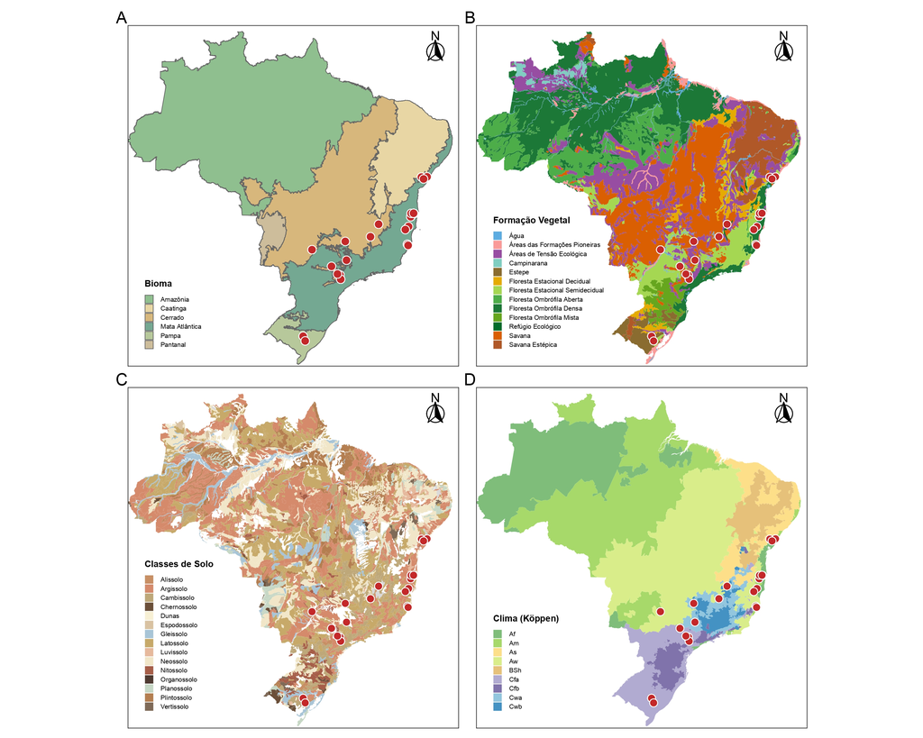

## Genotype-by-environment interaction

**GEI from the environmental perspective**

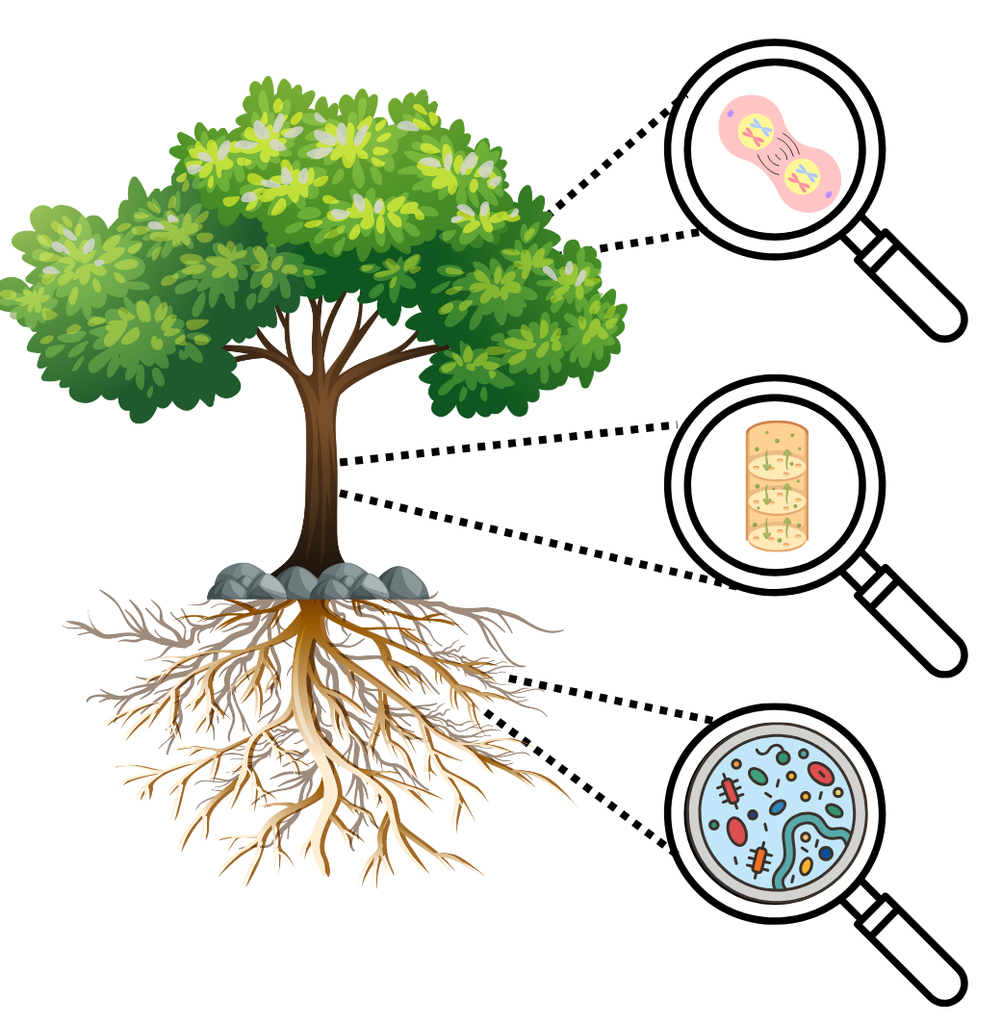

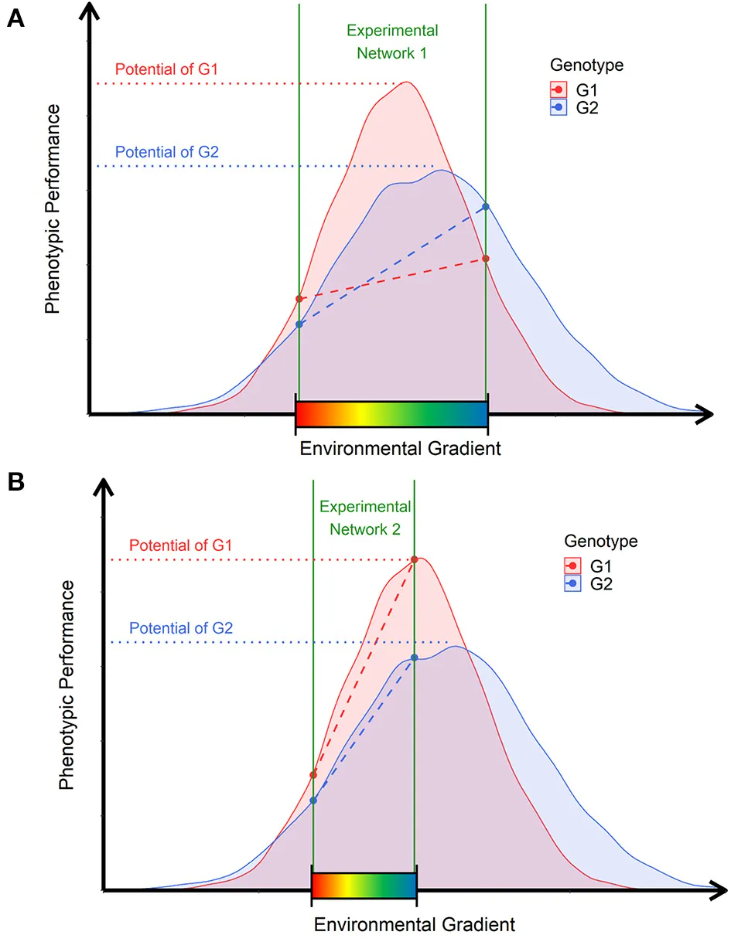

[Costa-Neto et al. (2021)](https://acsess.onlinelibrary.wiley.com/doi/10.1002/csc2.21312?medium=article&utm_source=researchgate.net)

## Environmics

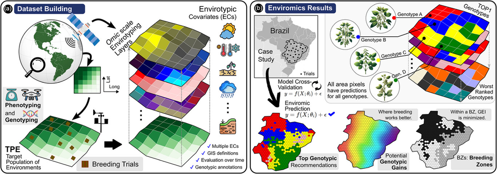

[Fritsche-Neto et al. (2025)](https://acsess.onlinelibrary.wiley.com/doi/10.1002/csc2.70175?utm_medium=article&utm_source=researchgate.net)

## Environmics

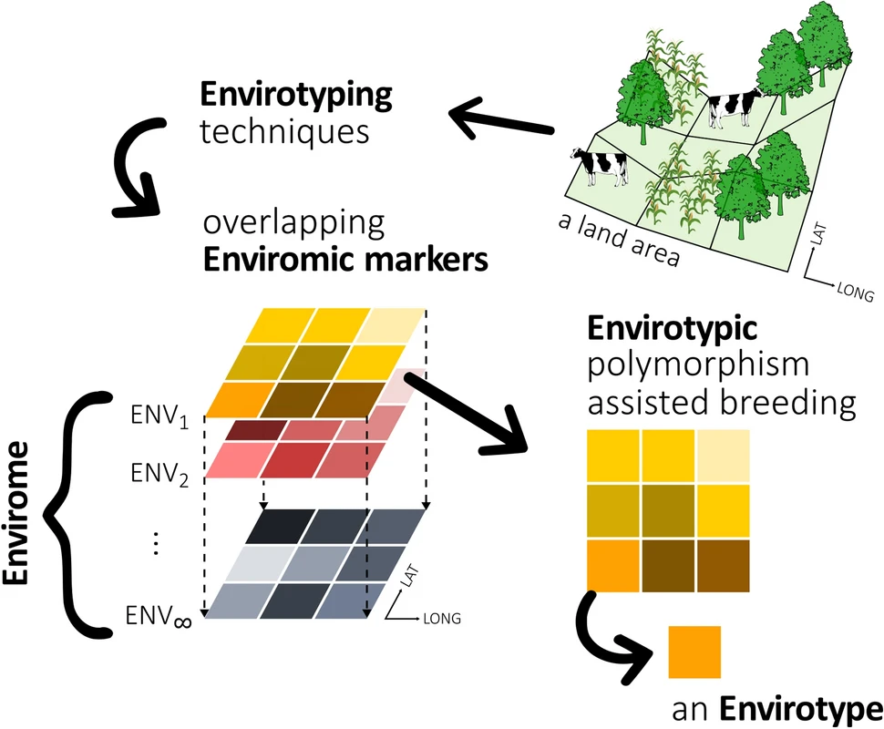

[Resende et al. (2021)](https://link.springer.com/article/10.1007/s00122-020-03684-z)

## Environmental covariate

[figure not shown]

[Xu (2016)](https://link.springer.com/article/10.1007/s00122-016-2691-5)

## Environmic marker

> An index vector derived from environmental (or envirotypic) covariates (ECs) which reflects the potential expression of a phenotype in a given space and time — Marcatti & Resende (2026)

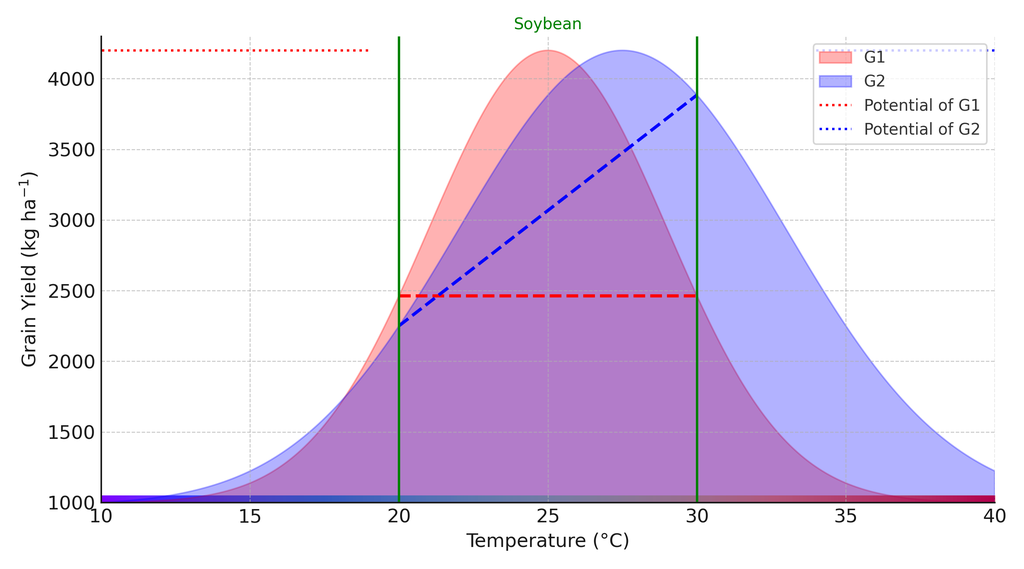

Maurício Araújo

## Environmic marker

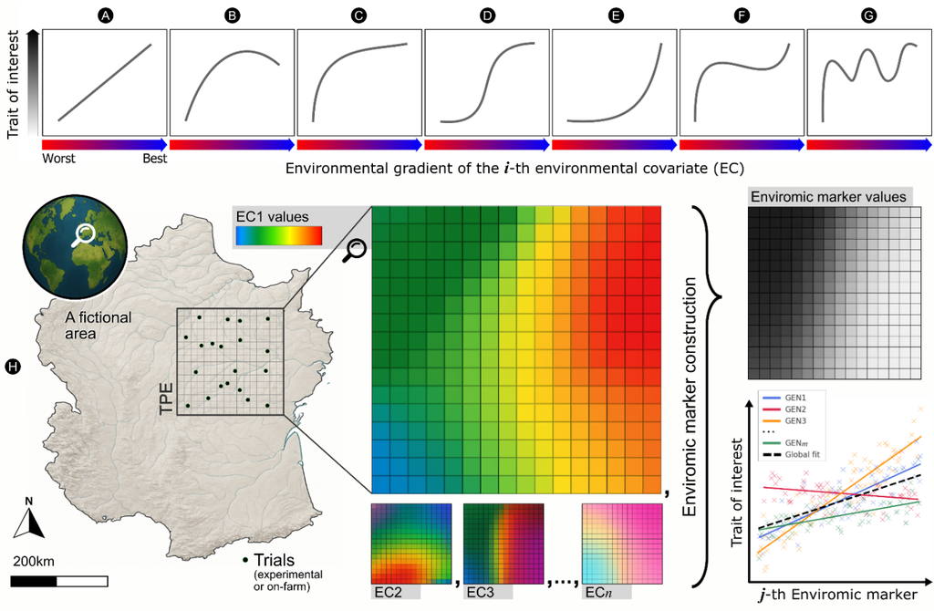

Marcatti & Resende (2026)

## Environmic marker

Extracted from (Marcatti & Resende, 2026):

- Linearity: The enviromic marker should have a linear relationship with the phenotype, analogous to treating SNPs in linear reaction models
- [Site potential]: A site with a high value for a given enviromic marker (a high envirotype) tends to offer greater potential for expressing the trait

## Environmic marker

- Most data is **freely available**
- National public databases
  - INMET
- International public databases
  - Ex: NASA, SoilGrids, WorldClim, etc.
- Data collected *in loco*
- Historical series
- Climate projections
  - Ex: IPCC

[figure not shown]

[Germano Costa-Neto](https://github.com/allogamous/EnvRtype)

## Environmic marker

**Quality control**

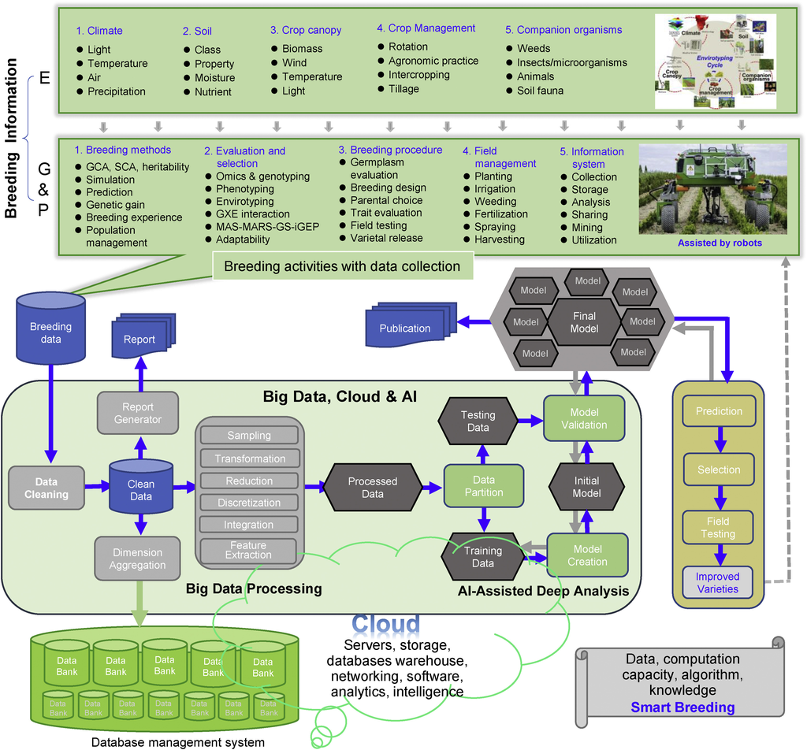

Xu et al. (2022)

## Environmics

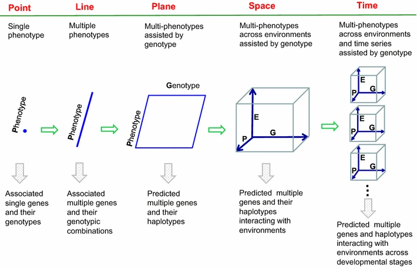

[Xu (2016)](https://link.springer.com/article/10.1007/s00122-016-2691-5)

## Environmics

**Plant breeding triangle**

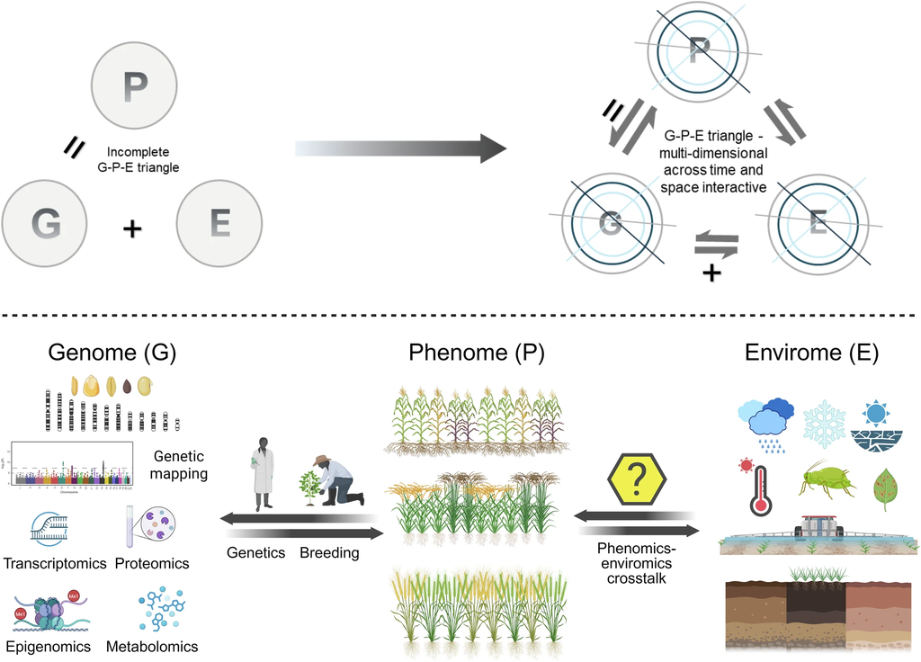

[Xu (2026)](https://www.nature.com/articles/s41467-026-73097-x)

## Environmics in plant breeding

## References

Couto, E. G. O., Chaves, S. F. S., Dias, K. O. G., Morales-Marroqu, J. A., Alves-Pereira, A., Colombo, C. A., & Zucchi, M. I. (2024). Training set optimization is a feasible alternative for perennial orphan crop domestication and germplasm management: an *Acrocomia aculeata* example. *Frontiers in Plant Science*, *15*, 1441683. https://doi.org/10.3389/fpls.2024.1441683

Fernández-González, J., Akdemir, D., & Isidro y Sánchez, J. (2023). A comparison of methods for training population optimization in genomic selection. *Theoretical and Applied Genetics*, *136*(3), 30. https://doi.org/10.1007/s00122-023-04265-6

Hickey, J. M., Chiurugwi, T., Mackay, I., & Powell, W. (2017). Genomic prediction unifies animal and plant breeding programs to form platforms for biological discovery. *Nature Genetics*, *49*(9), 1297–1303. https://doi.org/10.1038/ng.3920

Jarquin, D., Howard, R., Crossa, J., Beyene, Y., Gowda, M., Martini, J. W. R., Covarrubias Pazaran, G., Burgueño, J., Pacheco, A., Grondona, M., Wimmer, V., & Prasanna, B. M. (2020). Genomic prediction enhanced sparse testing for multi-environment trials. *G3 GenesGenomesGenetics*, *10*(8), 2725–2739. https://doi.org/10.1534/g3.120.401349

Marcatti, G. E., & Resende, R. T. (2026). The Enviromic marker. *Crop Breeding and Applied Biotechnology*, *26*, e54222611. https://doi.org/https://doi.org/10.1590/1984-70332026v26n1n1

Misztal, I., Aguilar, I., Lourenco, D., Ma, L., Steibel, J. P., & Toro, M. (2021). Emerging issues in genomic selection. *Journal of Animal Science*, *99*(6), skab092. https://doi.org/10.1093/jas/skab092

Voss-Fels, K. P., Cooper, M., & Hayes, B. J. (2019). Accelerating crop genetic gains with genomic selection. *Theoretical and Applied Genetics*, *132*(3), 669–686. https://doi.org/10.1007/s00122-018-3270-8

Wallace, J. G., Rodgers-Melnick, E., & Buckler, E. S. (2018). On the road to breeding 4.0: Unraveling the good, the bad, and the boring of crop quantitative genomics. *Annual Review of Genetics*, *52*(1), 421–444. https://doi.org/10.1146/annurev-genet-120116-024846

Werner, C. R., Gaynor, R. C., Sargent, D. J., Lillo, A., Gorjanc, G., & Hickey, J. M. (2023). Genomic selection strategies for clonally propagated crops. *Theoretical and Applied Genetics*, *136*(4), 74. https://doi.org/10.1007/s00122-023-04300-6